# Assignment 10: Predictive Modeling - Part 1

*How to do it?*:

- Open the Rmarkdown file of this assignment (link) in Rstudio.
- Right under each **question**, insert a code chunk (you can use the hotkey `Ctrl + Alt + I` to add a code chunk) and code the solution for the question.
- `Knit` the rmarkdown file (hotkey: `Ctrl + Alt + K`) to export an html.
- Publish the html file to your Githiub Page.

*Submission*: Submit the link on Github of the assignment to Canvas

1. Use the `Adult Census Income` dataset. We will predict the income (whether or not it is more than 50k or not) of an adult. Import the dataset. Partition the data into 80% training and 20% testing.

```r
# Import the Dataset
library(tidyverse)
df <- read_csv("https://bryantstats.github.io/math421/data/adult_census.csv")
str(df)
```

```
## spc_tbl_ [32,561 × 15] (S3: spec_tbl_df/tbl_df/tbl/data.frame)
##  $ age           : num [1:32561] 90 82 66 54 41 34 38 74 68 41 ...
##  $ workclass     : chr [1:32561] "?" "Private" "?" "Private" ...
##  $ fnlwgt        : num [1:32561] 77053 132870 186061 140359 264663 ...
##  $ education     : chr [1:32561] "HS-grad" "HS-grad" "Some-college" "7th-8th" ...
##  $ education.num : num [1:32561] 9 9 10 4 10 9 6 16 9 10 ...
##  $ marital.status: chr [1:32561] "Widowed" "Widowed" "Widowed" "Divorced" ...
##  $ occupation    : chr [1:32561] "?" "Exec-managerial" "?" "Machine-op-inspct" ...
##  $ relationship  : chr [1:32561] "Not-in-family" "Not-in-family" "Unmarried" "Unmarried" ...
##  $ race          : chr [1:32561] "White" "White" "Black" "White" ...
##  $ sex           : chr [1:32561] "Female" "Female" "Female" "Female" ...
##  $ capital.gain  : num [1:32561] 0 0 0 0 0 0 0 0 0 0 ...
##  $ capital.loss  : num [1:32561] 4356 4356 4356 3900 3900 ...
##  $ hours.per.week: num [1:32561] 40 18 40 40 40 45 40 20 40 60 ...
##  $ native.country: chr [1:32561] "United-States" "United-States" "United-States" "United-States" ...
##  $ income        : chr [1:32561] "<=50K" "<=50K" "<=50K" "<=50K" ...
##  - attr(*, "spec")=
##   .. cols(
##   ..   age = col_double(),
##   ..   workclass = col_character(),
##   ..   fnlwgt = col_double(),
##   ..   education = col_character(),
##   ..   education.num = col_double(),
##   ..   marital.status = col_character(),
##   ..   occupation = col_character(),
##   ..   relationship = col_character(),
##   ..   race = col_character(),
##   ..   sex = col_character(),
##   ..   capital.gain = col_double(),
##   ..   capital.loss = col_double(),
##   ..   hours.per.week = col_double(),
##   ..   native.country = col_character(),
##   ..   income = col_character()
##   .. )
##  - attr(*, "problems")=<externalptr>
```

```r
# Clean the Data

# Take out Columns
df <- df |> select(-fnlwgt)

# Set Target
df <- df |> rename(target=income)

# Correct Variable Types
df <- df |>
  mutate(target = as.factor(target),
         workclass = as.factor(workclass),
         education = as.factor(education),
         marital.status = as.factor(marital.status),
         occupation = as.factor(occupation),
         relationship = as.factor(relationship),
         race = as.factor(race),
         sex = as.factor(sex),
         native.country = as.factor(native.country))

# Handle NAs
df <- replace(df, df == 'Unknown' |
                  df == '?' |
                  df == 'Not Known', NA)

df <- drop_na(df)
```

```r
# Partition data into 80% training 20% testing
library(caret)
set.seed(2020)
splitIndex <- createDataPartition(df$target, p = .80,
                                  list = FALSE)
df_train <- df[ splitIndex,]
df_test <- df[-splitIndex,]
```

2. Practice Decision Tree. Do the follows:
- Use `rpart` package, create a decision tree with maximum depth of 3.

```r
library(rpart)
tree_model <- rpart(target ~ ., data = df_train,
                 control = rpart.control(maxdepth = 3))
```

- Calculate the accuracy of the model on the testing data. Notice that the positive outcome here is not `1` but `>50K` or `<50K`.

```r
# Predict on testing data
pred <- predict(tree_model, df_test, type = "class")

# Evaluate the predictions
cm <- confusionMatrix(data = pred, reference = df_test$target, positive = ">50K")
cm$overall[1]
```

```
##  Accuracy
## 0.8434754
```

- Plot the tree

```r
library(rattle)
```

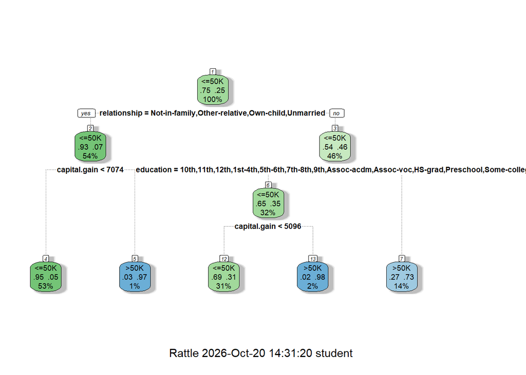

```r
fancyRpartPlot(tree_model)
```

- Plot the variable importance by the tree

```r
tree_model$variable.importance
```

```
##   relationship marital.status   capital.gain      education  education.num
##     1826.24452     1797.95870      815.58730      686.66966      686.66966
##            sex     occupation            age hours.per.week native.country
##      598.44249      522.30227      422.64281      248.15876       18.87253
##   capital.loss
##       12.02864
```

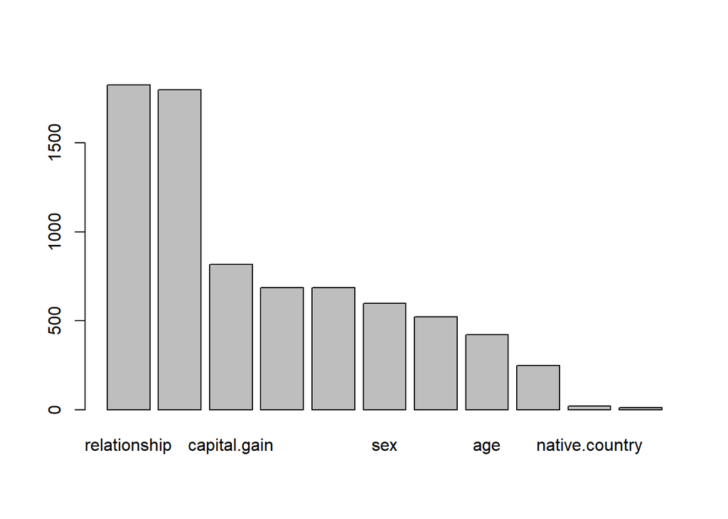

```r
# Plot
barplot(tree_model$variable.importance)
```

3. Create 3 more trees and compare the testing accuracy of these trees, which tree give the highest testing accuracy.

```r
# Tree 1: decrease `maxdepth`
tree_model1 <- rpart(target ~ ., data = df_train,
                 control = rpart.control(maxdepth = 2))

# Predict on testing data
pred1 <- predict(tree_model1, df_test, type = "class")

# Evaluate the predictions
cm1 <- confusionMatrix(data = pred1, reference = df_test$target, positive = ">50K")
cm1$overall[1]
```

```
##  Accuracy
## 0.8287183
```

```r
# Tree 2: increase `minsplit`
tree_model2 <- rpart(target ~ ., data = df_train,
                 control = rpart.control(minsplit = 50))

# Predict on testing data
pred2 <- predict(tree_model2, df_test, type = "class")

# Evaluate the predictions
cm2 <- confusionMatrix(data = pred2, reference = df_test$target, positive = ">50K")
cm2$overall[1]
```

```
##  Accuracy
## 0.8434754
```

```r
# Tree 3: increase `minbucket`
tree_model3 <- rpart(target ~ ., data = df_train,
                 control = rpart.control(minbucket = 5))

# Predict on testing data
pred3 <- predict(tree_model3, df_test, type = "class")

# Evaluate the predictions
cm3 <- confusionMatrix(data = pred3, reference = df_test$target, positive = ">50K")
cm3$overall[1]
```

```
##  Accuracy
## 0.8434754
```

**The testing accuracies are the same for the initial tree, tree 2, and tree 3. Tree 1 has a decreased accuracy because `maxdepth` decreased.**

4. Practice Random Forest. Do the follows:
- Use `randomForest` package, create a random forest of 1000 trees.

```r
library(randomForest)
forest_model <- randomForest(target ~ ., data=df_train, ntree = 1000)
```

- Calculate the accuracy of the model on the testing data.

```r
pred <- predict(forest_model, df_test, type = "class")

cm <- confusionMatrix(data = pred, reference = df_test$target, positive = ">50K")

cm$overall[1]
```

```
##  Accuracy
## 0.8632068
```

- Plot the variable importance by the forest

```r
# Get Importance
forest_importance <- sort(importance(forest_model)[, 1], decreasing = TRUE)
print(forest_importance)
```

```
##   capital.gain   relationship            age marital.status     occupation
##       960.2996       933.4401       898.9079       776.8846       720.3163
##      education hours.per.week  education.num      workclass   capital.loss
##       532.6833       526.8219       491.5587       292.8740       258.9956
## native.country           race            sex
##       189.7841       108.8725       105.8096
```

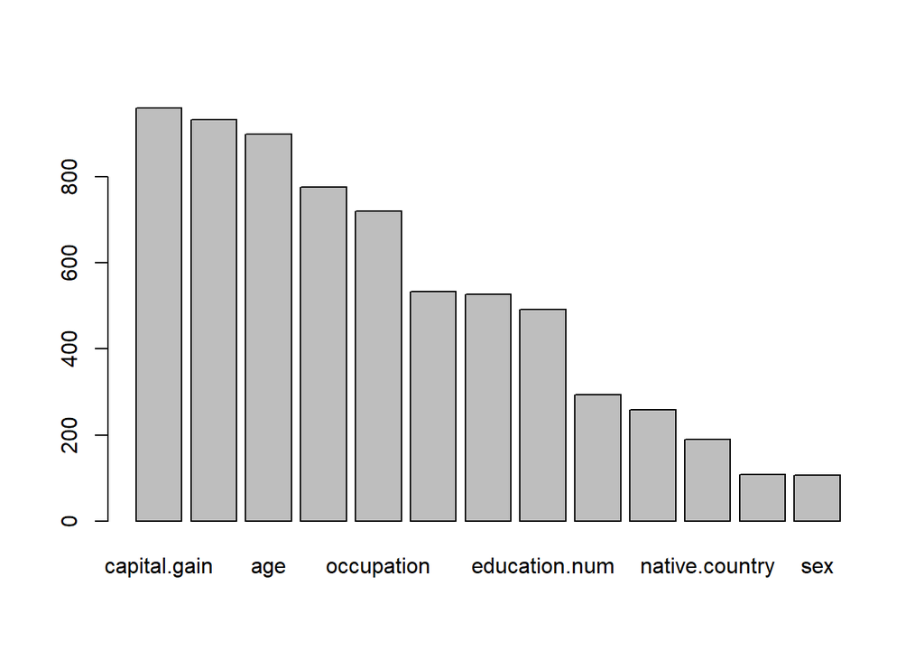

```r
# Plot
barplot(forest_importance)
```

5. Create 3 more forests and compare the testing accuracy of these forests, which forest give the highest testing accuracy.

```r
# Forest 1: Decrease `ntree` (number of trees grown)
forest_model1 <- randomForest(target ~ ., data=df_train, ntree = 500)

# Accuracy
pred1 <- predict(forest_model1, df_test, type = "class")

cm1 <- confusionMatrix(data = pred1, reference = df_test$target, positive = ">50K")

cm1$overall[1]
```

```
##  Accuracy
## 0.8640358
```

```r
forest_model$mtry
```

```
## [1] 3
```

```r
# Forest 2: Increase `mtry` (number of predictors sampled for spliting at each node)
forest_model2 <-randomForest(target ~ ., data=df_train, mtry = 5)

# Accuracy
pred2 <- predict(forest_model2, df_test, type = "class")

cm2 <- confusionMatrix(data = pred2, reference = df_test$target, positive = ">50K")

cm2$overall[1]
```

```
##  Accuracy
## 0.8580667
```

```r
# Forest 3: limit tree depth (`maxnodes`)
forest_model3 <- randomForest(target ~ ., data=df_train, maxnodes = 20)

# Accuracy
pred3 <- predict(forest_model3, df_test, type = "class")

cm3 <- confusionMatrix(data = pred3, reference = df_test$target, positive = ">50K")

cm3$overall[1]
```

```
##  Accuracy
## 0.8448019
```

**The best random forest model is forest 1 using the parameter `ntree = 500` which has an accuracy of 0.8640358.**

6. What is the best model (in term of testing accuracy) among all models (including trees and forests) you have trained?

**The best model is random forest 1 using the parameter `ntree = 500` which has an accuracy of 0.8640358.**